# Analyse statistique avec R

Université Paris Dauphine - Master 280 ISF Apprentissage

Pauline Chauveau

Alexandre Robin

2023

# Presentation

## Les données

Les donnéees proviennent de la “Base de données annuelles des accidents corporels de la crirculation routière” française pour l’année 2021.

- www.data.gouv.fr
- https://www.data.gouv.fr/fr/datasets/bases-de-donnees-annuelles-des-accidents-corporels-de-la-circulation-routiere-annees-de-2005-a-2021/#/resources

Elles sont réparties en 4 datasets distincts:

- usagers-2021.csv : données sur parties impliquées dans les accidents
- vehicules-2021.csv : données sur les véhicules impliqués dans les accidents
- lieux-2021.csv : données sur le lieu des accidents
- carcteristiques-2021.csv : caractéristiques des accidents

## Objectif

L’objectif de ce projet est de faire une prédiction de la variable `grav` qui représente la gravité du dommage corporel infligés aux victimes d’accidents de la circulation.

Le projet se divisera en plusierus étapes. D’abord l’aggrégation des données puis leur exploration et enfin leur exploitation.

## Bibliographie

Les différents sites et références utilisés dans ce projet.

- Documentation R : https://www.rdocumentation.org/
- Tutoriel caret : https://topepo.github.io/caret/index.html

> **Cette liste n’est pas exhaustive.**

# Outils

## Librairies

```r
library(caret)
library(corrplot)
library(dplyr)
library(kableExtra)
library(knitr)
library(ggcorrplot)
library(ggplot2)
library(knitr)
library(magrittr)
library(naniar)
library(rmdformats)
library(rpart)
library(sf)
library(tidyr)
library(tidyverse)
library(visdat)
```

## Rendu

```r
render_df <- function(df) {
  #' Formats dataframe for knitting
  #'
  #' @param df A data.frame

  df %>%
    kable() %>%
    kable_styling(
      full_width = TRUE,
      font_size = 10
    ) %>%
    scroll_box(width = "100%")
}
```

## Preprocessing

```r
set_numericals <- function(data, list_var){
  require(dplyr, install.packages('dplyr'))
  list_var <- unlist(list_var)
  data <- data %>% mutate_at(vars(matches(list_var)), as.integer)
  return(data)
}

set_factors <- function(data, list_var){
  require(dplyr, install.packages('dplyr'))
  list_var <- unlist(list_var)
  data <- data %>% mutate_at(vars(matches(list_var)), as.factor)
  return(data)
}

set_strings <- function(data, list_var){
  require(dplyr, install.packages('dplyr'))
  list_var <- unlist(list_var)
  data <- data %>% mutate_at(vars(matches(list_var)), as.character)
  return(data)
}

set_data <- function(data, var_numericals, var_factors, var_strings){
  if(length(var_numericals)!=0)
    data <- set_numericals(data, var_numericals)
  if(length(var_factors)!=0)
    data <- set_factors(data, var_factors)
  if(length(var_strings)!=0)
    data <- set_strings(data, var_strings)
  return(data)
}

del_vars <- function(data, vars){
  vars <- unlist(vars)
  data <- data %>% select(-vars)
  return(data)
}

get_missing <- function(df){
  variables <- names(df)
  dtypes <- sapply(df, class)
  count <- sapply(df, length)
  unique <- sapply(df, function(x) length(unique(na.omit(x))))
  missing <- sapply(df, function(x) sum(is.na(x)))
  missing_prop <- round(missing/count*100, 2)
  output <- data.frame(variable=variables,
                       dtype=dtypes,
                       count=count,
                       unique=unique,
                       missing=missing,
                       missing_prop=missing_prop)
  return(output)
}

get_dtypes <- function(df){
  variables <- names(df)
  dtypes <- sapply(df, class)
  return(data.frame(variable=variables, dtype=dtypes))
}

set_dtypes_df <- function(df){
  rownames(df) <- df$variable
  df <- df %>% select(-variable)
  df <- df %>% t()
  return(df)
}
```

## EDA

```r
most_common <- function(vect){
  return(names(sort(table(vect), decreasing=T)[1]))
}

get_countplot <- function(data, categorical_var) {
  #' Plots a countplot
  #'
  #' @param data A data.frame object
  #' @param categorical_var A character object, colname of data

  ggplot(
    data,
    aes(x = data[, categorical_var], fill = data[, categorical_var])
  ) +
    geom_bar() +
    labs(x = categorical_var, fill = categorical_var)
}

get_boxplot <- function(data, categorical_var, numerical_var) {
  #' Plots a boxplot
  #'
  #' @param data A data.frame object
  #' @param categorical_var A character object, colname of data
  #' @param numerical_var A character object, colname of data

  ggplot(
    data,
    aes(
      x = data[, categorical_var],
      y = data[, numerical_var],
      colour = data[, categorical_var],
      fill = data[, categorical_var]
    )
  ) +
    geom_boxplot(
      alpha = 0.5,
      outlier.alpha = 0
    ) +
    geom_jitter(
      width = 0.25
    ) +
    stat_summary(
      fun = mean,
      colour = "black",
      geom = "point",
      shape = 18,
      size = 2
    ) +
    labs(
      x = categorical_var, y = numerical_var,
      colour = categorical_var, fill = categorical_var,
      title = paste(categorical_var, "vs", numerical_var)
    )
}

get_multivar_plot <- function(data, target, var_quant, var_qual) {
  #' Multivariate plot
  #'
  #' @param data A data.frame object
  #' @param target A character object, colname of data
  #' @param var_quant A character object, colname of data
  #' @param var_qual A character object, colname of data

  ggplot(
    data,
    aes_string(
      x = var_quant,
      y = target, color = var_qual
    )
  ) +
    geom_point() +
    geom_smooth(method = "lm")
}

get_hist_and_density <- function(data, var, binwidth = 10) {
  #' Plots histogram and density
  #'
  #' @param data A data.frame object
  #' @param var A character object, colname of data
  #' @param binwidth

  ggplot(
    data,
    aes(x = data[, var])
  ) +
    geom_histogram(
      aes(y = ..density..),
      colour = 1,
      fill = "white",
      binwidth = binwidth
    ) +
    geom_density(alpha = .2, fill = "#FF6666") +
    labs(x = var, title = paste(var, "distribution"))
}

plot_cat_vs_cat <- function(data, x, y) {
  #' Jitterplot
  #'
  #' @param data A data.frame object
  #' @param x A character object, colname of data
  #' @param y A character object, colname of data

  ggplot(
    data,
    aes(
      x = data[, x],
      y = data[, y]
    )
  ) +
    geom_jitter(
      aes(color = data[, x]),
      width = 0.25
    ) +
    labs(
      x = x, y = y,
      colour = x, fill = x,
      title = paste(x, "vs", y)
    )
}
```

# Preprocessing

## Caractéristiques

### Acquisition

```r
original_caract <- read.csv2(
  'carcteristiques-2021.csv',
  header=TRUE,
  sep=';'
)
caract <- original_caract
```

#### head

```r
original_caract %>% head() %>% render_df()
```

| Num_Acc | jour | mois | an | hrmn | lum | dep | com | agg | int | atm | col | adr | lat | long |
| --- | --- | --- | --- | --- | --- | --- | --- | --- | --- | --- | --- | --- | --- | --- |
| 2.021e+11 | 30 | 11 | 2021 | 07:32 | 2 | 30 | 30319 | 1 | 1 | 1 | 1 | CD 981 | 44.03896 | 4.348022 |
| 2.021e+11 | 25 | 9 | 2021 | 14:20 | 1 | 51 | 51544 | 1 | 3 | 1 | 3 | Aire de repos croisement D20E9 après sortie D977 | 49.24213 | 4.554546 |
| 2.021e+11 | 15 | 7 | 2021 | 07:55 | 1 | 85 | 85048 | 2 | 1 | 7 | 6 | 15 rue François Nicolas | 46.92195 | -0.964460 |
| 2.021e+11 | 27 | 3 | 2021 | 19:45 | 5 | 93 | 93005 | 2 | 2 | 3 | 6 | Route de Mitry | 48.94936 | 2.519664 |
| 2.021e+11 | 25 | 2 | 2021 | 07:20 | 5 | 76 | 76429 | 2 | 1 | 1 | 2 | PARIS. ROUTE DE | 49.40838 | 1.145810 |
| 2.021e+11 | 23 | 11 | 2021 | 11:10 | 1 | 68 | 68004 | 2 | 3 | 1 | 2 | Rue Charles Edouard Amiot | 47.61424 | 7.234336 |

#### str

```r
original_caract %>% str()
```

```
## 'data.frame':    56518 obs. of  15 variables:
##  $ Num_Acc: num  2.02e+11 2.02e+11 2.02e+11 2.02e+11 2.02e+11 ...
##  $ jour   : int  30 25 15 27 25 23 13 21 29 16 ...
##  $ mois   : int  11 9 7 3 2 11 12 11 12 10 ...
##  $ an     : int  2021 2021 2021 2021 2021 2021 2021 2021 2021 2021 ...
##  $ hrmn   : chr  "07:32" "14:20" "07:55" "19:45" ...
##  $ lum    : int  2 1 1 5 5 1 5 1 2 1 ...
##  $ dep    : chr  "30" "51" "85" "93" ...
##  $ com    : chr  "30319" "51544" "85048" "93005" ...
##  $ agg    : int  1 1 2 2 2 2 2 2 2 2 ...
##  $ int    : int  1 3 1 2 1 3 9 1 2 1 ...
##  $ atm    : int  1 1 7 3 1 1 1 1 2 1 ...
##  $ col    : int  1 3 6 6 2 2 1 3 3 3 ...
##  $ adr    : chr  "CD 981" "Aire de repos croisement D20E9 après sortie D977" "15 rue François Nicolas" "Route de Mitry" ...
##  $ lat    : num  44 49.2 46.9 48.9 49.4 ...
##  $ long   : num  4.348 4.555 -0.964 2.52 1.146 ...
```

#### summary

```r
original_caract %>% summary() %>% render_df()
```

|  | Num_Acc | jour | mois | an | hrmn | lum | dep | com | agg | int | atm | col | adr | lat | long |
| --- | --- | --- | --- | --- | --- | --- | --- | --- | --- | --- | --- | --- | --- | --- | --- |
|  | Min. :2.021e+11 | Min. : 1.00 | Min. : 1.000 | Min. :2021 | Length:56518 | Min. :1.000 | Length:56518 | Length:56518 | Min. :1.000 | Min. :1.000 | Min. :-1.000 | Min. :-1.000 | Length:56518 | Min. :-23.40 | Min. :-178.086 |
|  | 1st Qu.:2.021e+11 | 1st Qu.: 8.00 | 1st Qu.: 4.000 | 1st Qu.:2021 | Class :character | 1st Qu.:1.000 | Class :character | Class :character | 1st Qu.:1.000 | 1st Qu.:1.000 | 1st Qu.: 1.000 | 1st Qu.: 3.000 | Class :character | 1st Qu.: 44.65 | 1st Qu.: 1.278 |
|  | Median :2.021e+11 | Median :16.00 | Median : 7.000 | Median :2021 | Mode :character | Median :1.000 | Mode :character | Mode :character | Median :2.000 | Median :1.000 | Median : 1.000 | Median : 3.000 | Mode :character | Median : 47.79 | Median : 2.389 |
|  | Mean :2.021e+11 | Mean :15.76 | Mean : 6.867 | Mean :2021 | NA | Mean :1.835 | NA | NA | Mean :1.643 | Mean :2.077 | Mean : 1.624 | Mean : 4.005 | NA | Mean : 44.40 | Mean : 2.310 |
|  | 3rd Qu.:2.021e+11 | 3rd Qu.:23.00 | 3rd Qu.:10.000 | 3rd Qu.:2021 | NA | 3rd Qu.:2.000 | NA | NA | 3rd Qu.:2.000 | 3rd Qu.:2.000 | 3rd Qu.: 1.000 | 3rd Qu.: 6.000 | NA | 3rd Qu.: 48.86 | 3rd Qu.: 4.810 |
|  | Max. :2.021e+11 | Max. :31.00 | Max. :12.000 | Max. :2021 | NA | Max. :5.000 | NA | NA | Max. :2.000 | Max. :9.000 | Max. : 9.000 | Max. : 7.000 | NA | Max. : 51.06 | Max. : 168.107 |

#### missing

```r
original_caract %>% get_missing() %>% render_df()
```

|  | variable | dtype | count | unique | missing | missing_prop |
| --- | --- | --- | --- | --- | --- | --- |
| Num_Acc | Num_Acc | numeric | 56518 | 56518 | 0 | 0 |
| jour | jour | integer | 56518 | 31 | 0 | 0 |
| mois | mois | integer | 56518 | 12 | 0 | 0 |
| an | an | integer | 56518 | 1 | 0 | 0 |
| hrmn | hrmn | character | 56518 | 1374 | 0 | 0 |
| lum | lum | integer | 56518 | 5 | 0 | 0 |
| dep | dep | character | 56518 | 107 | 0 | 0 |
| com | com | character | 56518 | 11150 | 0 | 0 |
| agg | agg | integer | 56518 | 2 | 0 | 0 |
| int | int | integer | 56518 | 9 | 0 | 0 |
| atm | atm | integer | 56518 | 10 | 0 | 0 |
| col | col | integer | 56518 | 8 | 0 | 0 |
| adr | adr | character | 56518 | 29670 | 0 | 0 |
| lat | lat | numeric | 56518 | 54618 | 0 | 0 |
| long | long | numeric | 56518 | 54921 | 0 | 0 |

#### visual

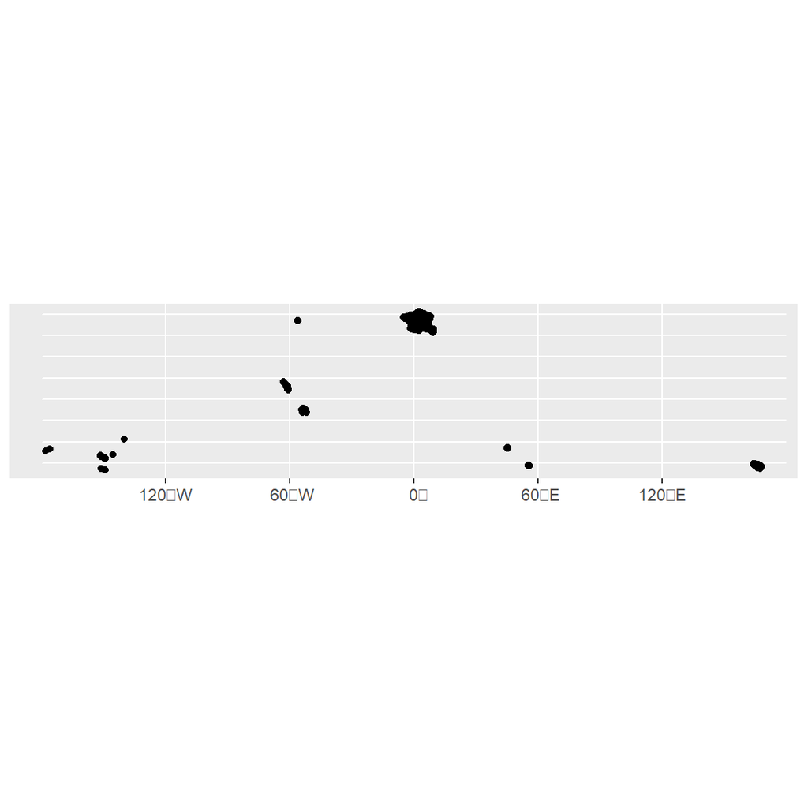

```r
coordinates <- st_as_sf(original_caract, coords = c("long", "lat"), crs = 4326)
ggplot(coordinates) +
  geom_sf()
```

### Featuring

#### Missing

```r
caract <- caract %>% mutate_all(~ifelse(. == 'N/A', NA, .))
caract <- caract %>% mutate(across(-c(long,lat), ~ifelse(. == '-1', NA, .)))
caract <- caract %>% mutate(across(-c(long,lat), ~ifelse(.==-1, NA, .)))
caract %>% get_missing() %>% render_df()
```

|  | variable | dtype | count | unique | missing | missing_prop |
| --- | --- | --- | --- | --- | --- | --- |
| Num_Acc | Num_Acc | numeric | 56518 | 56518 | 0 | 0.00 |
| jour | jour | integer | 56518 | 31 | 0 | 0.00 |
| mois | mois | integer | 56518 | 12 | 0 | 0.00 |
| an | an | integer | 56518 | 1 | 0 | 0.00 |
| hrmn | hrmn | character | 56518 | 1374 | 0 | 0.00 |
| lum | lum | integer | 56518 | 5 | 0 | 0.00 |
| dep | dep | character | 56518 | 107 | 0 | 0.00 |
| com | com | character | 56518 | 11150 | 0 | 0.00 |
| agg | agg | integer | 56518 | 2 | 0 | 0.00 |
| int | int | integer | 56518 | 9 | 0 | 0.00 |
| atm | atm | integer | 56518 | 9 | 8 | 0.01 |
| col | col | integer | 56518 | 7 | 20 | 0.04 |
| adr | adr | character | 56518 | 29669 | 572 | 1.01 |
| lat | lat | numeric | 56518 | 54618 | 0 | 0.00 |
| long | long | numeric | 56518 | 54921 | 0 | 0.00 |

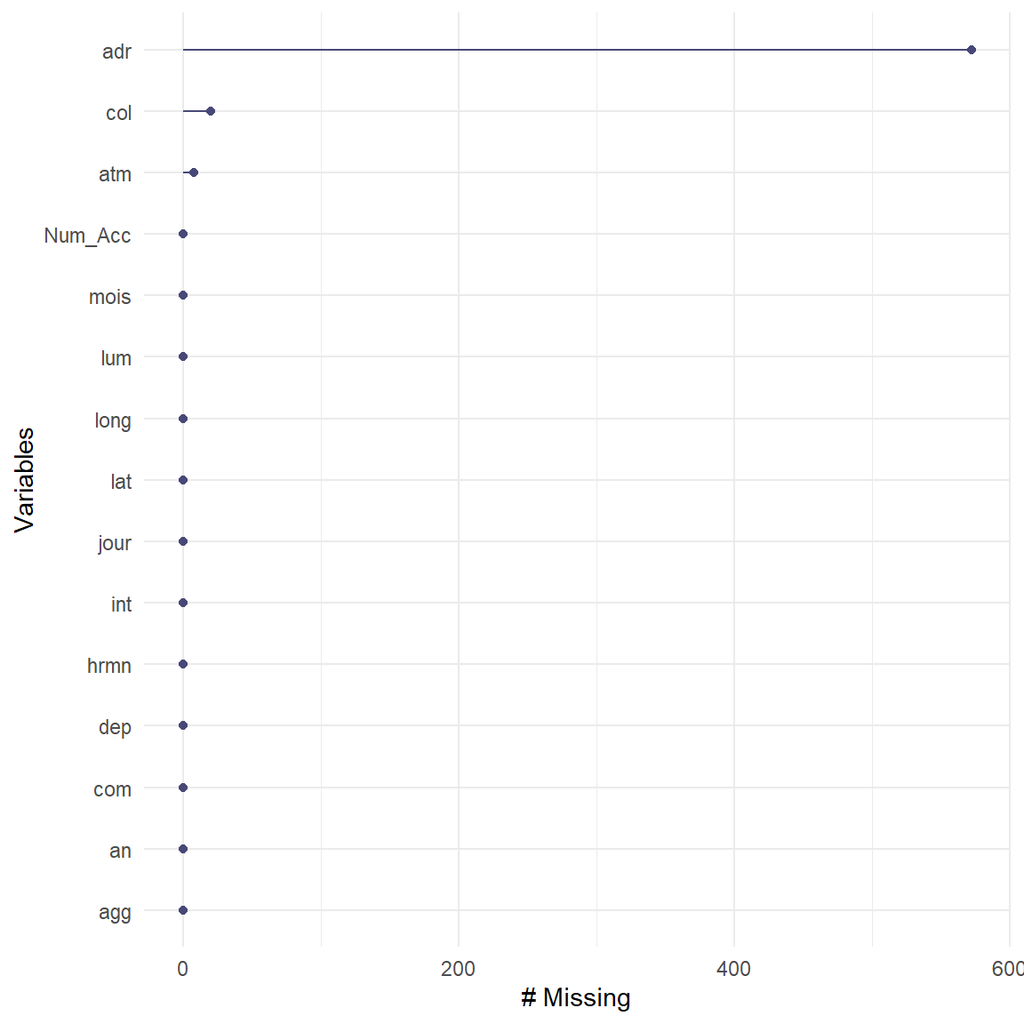

```r
caract %>% gg_miss_var()
```

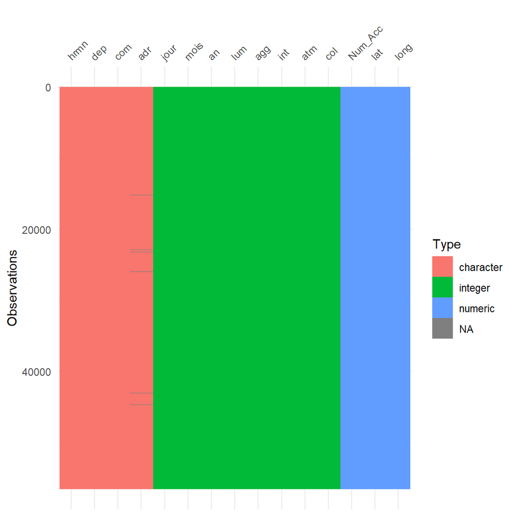

```r
caract %>% vis_dat(warn_large_data=FALSE)
```

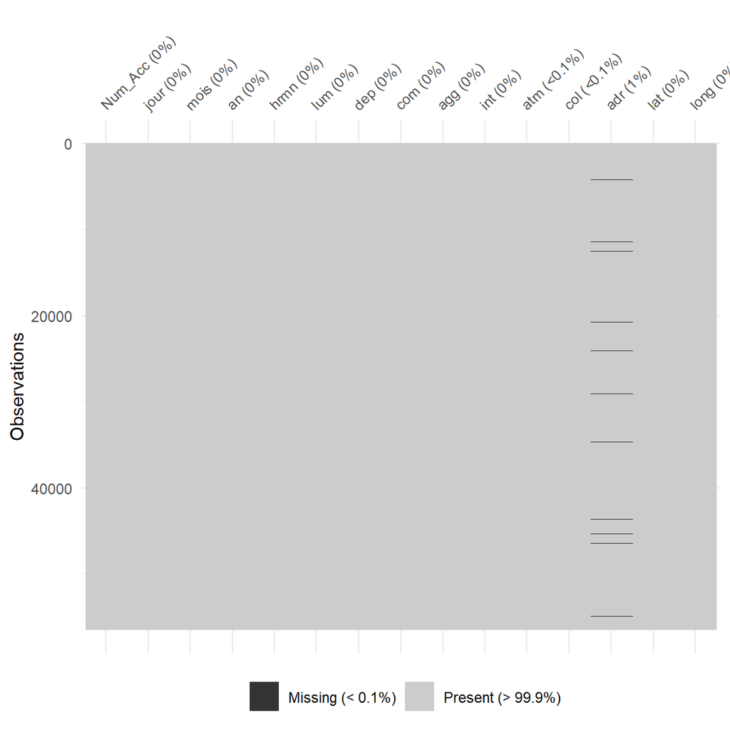

```r
caract %>% vis_miss(warn_large_data=FALSE)
```

#### Engineering

```r
caract$hh <- as.numeric(substr(caract$hrmn,1,2))

caract <- caract %>%
  mutate(hh, plage_hh = if_else(hh <= 5, 'nuit',
                                if_else(hh <= 12, 'matin',
                                        if_else(hh <= 18 , 'apres-midi',
                                                if_else(hh <= 22, 'soirée', 'nuit'))))
         ) %>%
  mutate(mois, saison = if_else(mois <= 3, 'hiver',
                                if_else(mois <= 6, 'printemps',
                                        if_else(mois <= 9, 'été','automne')))
         ) %>%
  mutate(int, inter = if_else(int == 1, 'Hors intersection', 'intersection')) %>%
  mutate(atm, meteo = if_else(atm == 1, 'normale', 'risqué')) %>%
  mutate(col, collision = if_else(col == 7, 'oui', 'non')) %>%
  mutate(lum, eclairage = if_else(lum %in% c(1,2,5), 'éclairé', 'peu éclairé')) %>%
  filter( (lat >= 40 & lat <= 55) & (long >= - 6 & long <= 12)) #drop dom tom
```

#### Setting

```r
strings <- list(
  'Num_Acc' # keep for join
)
factors <- list(
  'plage_hh',
  'eclairage', # from lum
  'agg',
  'inter',
  'meteo',
  'collision',
  'saison'
)

numericals <- list(
  'lat',
  'long'
)

to_drop <- list(
  'adr', # too many mod
  'com', # too many mod
  'jour', # not relevant
  'an', # only 1 mod
  'hrmn', # only keep hour
  'hh', # keep plage_hh instead
  'mois', # keep saison instead
  'int', # keep inter instead
  'dep', # repetitive with lat/long
  'atm', # keep meteo
  'lum',
  'col' # keep collision
)

caract <- caract %>% set_data(numericals, factors, strings)
caract <- caract %>% del_vars(to_drop)
```

### Summary

#### head

```r
caract %>% head() %>% render_df()
```

| Num_Acc | agg | lat | long | plage_hh | saison | inter | meteo | collision | eclairage |
| --- | --- | --- | --- | --- | --- | --- | --- | --- | --- |
| 202100000001 | 1 | 44 | 4 | matin | automne | Hors intersection | normale | non | éclairé |
| 202100000002 | 1 | 49 | 4 | apres-midi | été | intersection | normale | non | éclairé |
| 202100000003 | 2 | 46 | 0 | matin | été | Hors intersection | risqué | non | éclairé |
| 202100000004 | 2 | 48 | 2 | soirée | hiver | intersection | risqué | non | éclairé |
| 202100000005 | 2 | 49 | 1 | matin | hiver | Hors intersection | normale | non | éclairé |
| 202100000006 | 2 | 47 | 7 | matin | automne | intersection | normale | non | éclairé |

#### str

```r
caract %>% str()
```

```
## 'data.frame':    53540 obs. of  10 variables:
##  $ Num_Acc  : chr  "202100000001" "202100000002" "202100000003" "202100000004" ...
##  $ agg      : Factor w/ 2 levels "1","2": 1 1 2 2 2 2 2 2 2 2 ...
##  $ lat      : int  44 49 46 48 49 47 45 48 48 48 ...
##  $ long     : int  4 4 0 2 1 7 5 2 2 2 ...
##  $ plage_hh : Factor w/ 4 levels "apres-midi","matin",..: 2 1 2 4 2 2 4 1 2 1 ...
##  $ saison   : Factor w/ 4 levels "automne","été",..: 1 2 2 3 3 1 1 1 1 1 ...
##  $ inter    : Factor w/ 2 levels "Hors intersection",..: 1 2 1 2 1 2 2 2 1 2 ...
##  $ meteo    : Factor w/ 2 levels "normale","risqué": 1 1 2 2 1 1 1 2 1 1 ...
##  $ collision: Factor w/ 2 levels "non","oui": 1 1 1 1 1 1 1 1 1 1 ...
##  $ eclairage: Factor w/ 2 levels "éclairé","peu éclairé": 1 1 1 1 1 1 1 1 1 1 ...
```

#### summary

```r
caract %>% summary() %>% render_df()
```

|  | Num_Acc | agg | lat | long | plage_hh | saison | inter | meteo | collision | eclairage |
| --- | --- | --- | --- | --- | --- | --- | --- | --- | --- | --- |
|  | Length:53540 | 1:19020 | Min. :41.00 | Min. :-5.00 | apres-midi:23240 | automne :14331 | Hors intersection:33986 | normale:42463 | non :48144 | éclairé :48520 |
|  | Class :character | 2:34520 | 1st Qu.:45.00 | 1st Qu.: 1.00 | matin :16933 | été :14897 | intersection :19554 | risqué :11069 | oui : 5379 | peu éclairé: 5020 |
|  | Mode :character | NA | Median :48.00 | Median : 2.00 | nuit : 4907 | hiver :10512 | NA | NA’s : 8 | NA’s: 17 | NA |
|  | NA | NA | Mean :46.45 | Mean : 2.35 | soirée : 8460 | printemps:13800 | NA | NA | NA | NA |
|  | NA | NA | 3rd Qu.:48.00 | 3rd Qu.: 4.00 | NA | NA | NA | NA | NA | NA |
|  | NA | NA | Max. :51.00 | Max. : 9.00 | NA | NA | NA | NA | NA | NA |

#### missing

```r
caract %>% get_missing() %>% render_df()
```

|  | variable | dtype | count | unique | missing | missing_prop |
| --- | --- | --- | --- | --- | --- | --- |
| Num_Acc | Num_Acc | character | 53540 | 53540 | 0 | 0.00 |
| agg | agg | factor | 53540 | 2 | 0 | 0.00 |
| lat | lat | integer | 53540 | 11 | 0 | 0.00 |
| long | long | integer | 53540 | 15 | 0 | 0.00 |
| plage_hh | plage_hh | factor | 53540 | 4 | 0 | 0.00 |
| saison | saison | factor | 53540 | 4 | 0 | 0.00 |
| inter | inter | factor | 53540 | 2 | 0 | 0.00 |
| meteo | meteo | factor | 53540 | 2 | 8 | 0.01 |
| collision | collision | factor | 53540 | 2 | 17 | 0.03 |
| eclairage | eclairage | factor | 53540 | 2 | 0 | 0.00 |

### Saving

```r
caract_dtypes <- caract %>% get_dtypes()

caract %>% write.csv2('preprocessed_caract.csv', row.names=FALSE)
caract_dtypes %>% write.csv2('preprocessed_caract_dtypes.csv', row.names=FALSE)
```